# practical_exercise_3, Methods 3, 2021, autumn semester

Mie Buchhave Søgaard

04.10.2021

# Exercises and objectives

The objectives of the exercises of this assignment are:  
1) Download and organise the data and model and plot staircase responses based on fits of logistic functions  
2) Fit multilevel models for response times  
3) Fit multilevel models for count data

## Exercise 1

Data used in the assignment: https://osf.io/ecxsj/files/ (*experiment 2*)

Data is associated with Experiment 2 of the article at the following DOI: https://doi.org/10.1016/j.concog.2019.03.007

### 1) Put the data from all subjects into a single data frame

```r
df <- read_bulk(directory = "experiment_2",
                           fun = read_csv)
```

### 2) Describe the data and construct extra variables from the existing variables

**i. add a variable to the data frame and call it *correct* (have it be a *logical* variable). Assign a 1 to each row where the subject indicated the correct answer and a 0 to each row where the subject indicated the incorrect answer (**Hint:** the variable *obj.resp* indicates whether the subject answered “even”, *e* or “odd”, *o*, and the variable *target_type* indicates what was actually presented.**

```r
df$correct <- as.factor(ifelse((df$target.type == "odd" & df$obj.resp == "o") | (df$target.type == "even" & df$obj.resp == "e"), 1, 0))
```

**ii. describe what the following variables in the data frame contain. For each of them, indicate and argue for what `class` they should be classified into, e.g. *factor*, *numeric* etc.**

*trial.type* : The different types of trials. Should be classified as charactor or factor.  
*pas* : Indicates how clearly the subject felt to have seen the stimulus (Four categories from 1 (did not observe target) to 4 (did see the target clearly). These should be treated categorically (independent of eachother) and thus should be coded as factor.  
*trial* : Trial number for each participant. It could be argued that this variable should be classified into factor as each trial are some sort of categorical in the sense that no trial 1.65 exists. However, trials are randomized and trial 1 for subject 1 might not be identica to trial 1 for subject 4. Additionally, it could be argued that trials a sense be dependent of earlier trials and that trials in a bigger sense whould be seen on a continuum (one being after the other), and therefore classify *trial* as a numeric variabel.  
*target.contrast* : The contrast of the low-contrast target digit presented between cue and target. Should be treated as numeric.  
*cue* : The cue presented in the beginning of the trial (changes after 12 trials). Should be treated as a factor as these cues are independent of each other.  
*task* : Indicating the amount of digits (e.g. singles: 2:4, pairs: 24:57, quadrouplet: 2468:3579). Should be treated as character or factor.  
*target.type* : Whether the target shown was an even or odd number, Should be treated as character or factor.  
*rt.subj* : Reaction time for subject’s response (seconds). As these are values on a continuum, this variable should be numeric.  
*obj.resp* : Whether the subject indicated that the target was even (*e*) or odd (*o*). Should be treated as character or factor (categorical).  
*subject* : Unique identifier for each participant. Should be treated as a factor, as these numbers are indicators os subject and therefore categorical and independent of each other.  
*correct* : Logical argument indicating whether the subject indicated the correct answer (1 = correct, 0 = incorrect). These are dummy variables with no numerical quantitative meaning and thus should be classified as factor.

```r
df$pas <- as.factor(df$pas)
df$cue <- as.factor(df$cue)
df$task <- as.factor(df$task)
df$subject <- as.numeric(df$subject) # for analysis later
df$subject <- as.factor(df$subject)

df <- df %>%
  select(trial.type, pas, trial, target.contrast, cue, task, target.type, rt.subj, rt.obj, obj.resp, subject, correct)
```

**iii. for the staircasing part **only**, create a plot for each subject where you plot the estimated function (on the *target.contrast* range from 0-1) based on the fitted values of a model (use `glm`) that models *correct* as dependent on *target.contrast*. These plots will be our *no-pooling* model. Comment on the fits - do we have enough data to plot the logistic functions?**

```r
df_f <- df %>%
  filter(trial.type == "staircase")

inv.logit <- function(x) exp(x) / (1 + exp(x)) # defining the function for inverse logit
```

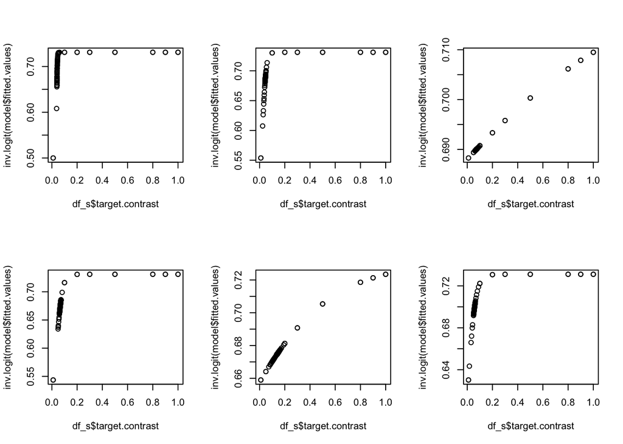

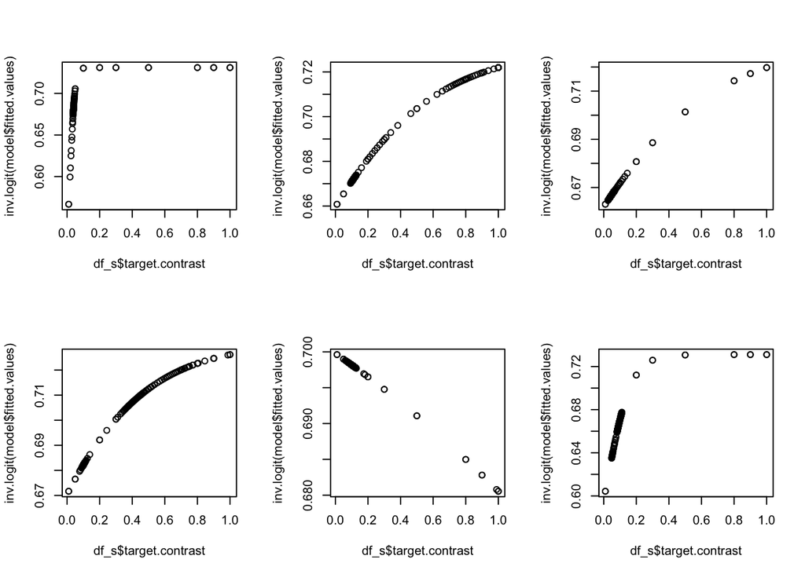

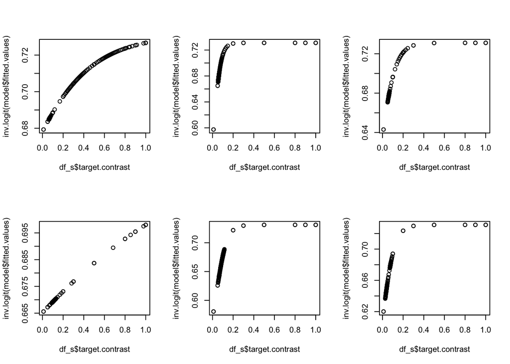

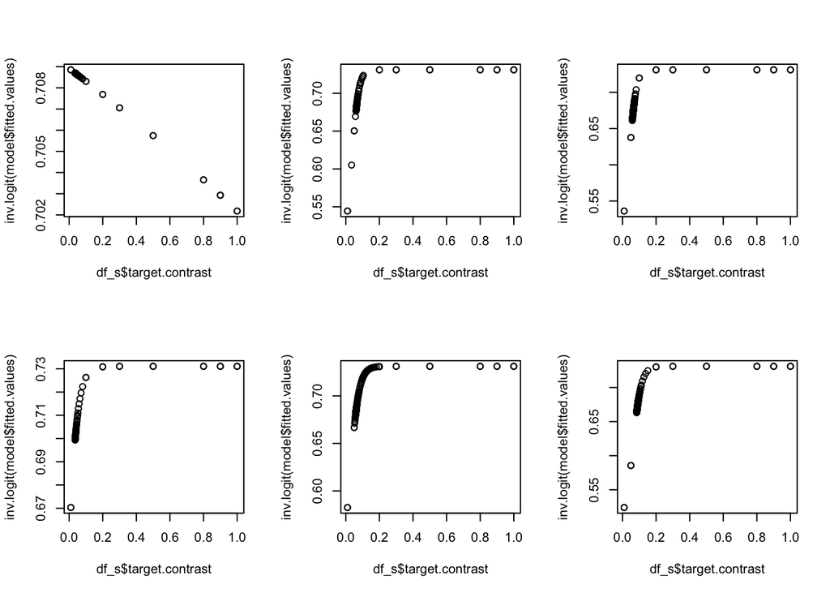

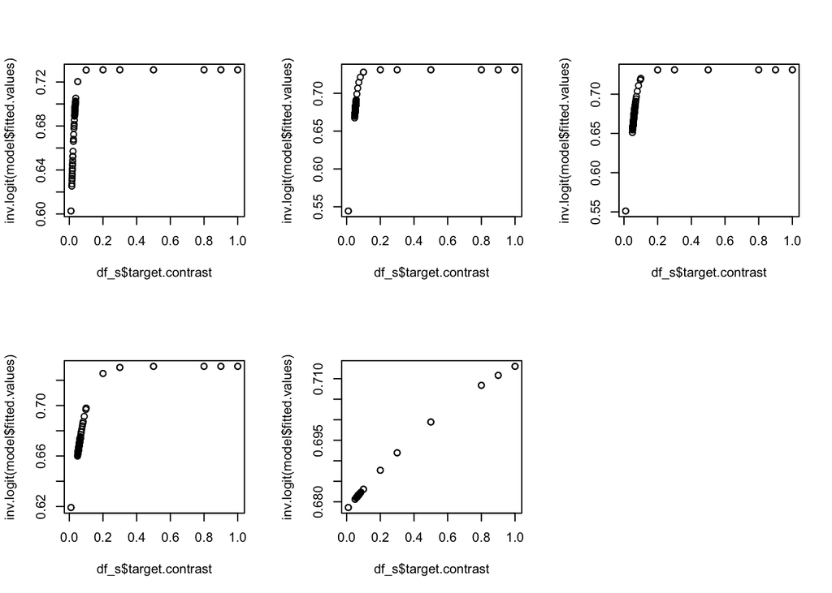

```r
par(mfrow = c(2, 3))

for (i in 1:29) {

  df_s <- df_f %>%
    filter(subject == i)

  model <- glm(correct ~ target.contrast, data = df_s, family=binomial)

  plot(df_s$target.contrast, inv.logit(model$fitted.values))

}
```

Looking at the plots, the estimated functions do not look very good. It doesn’t look like there is enough data.

**iv. on top of those plots, add the estimated functions (on the *target.contrast* range from 0-1) for each subject based on partial pooling model (use `glmer` from the package `lme4`) where unique intercepts and slopes for *target.contrast* are modelled for each *subject***

```r
model_2 <- lme4::glmer(correct ~ target.contrast + (1 | subject), data = df_f, family = binomial)
```

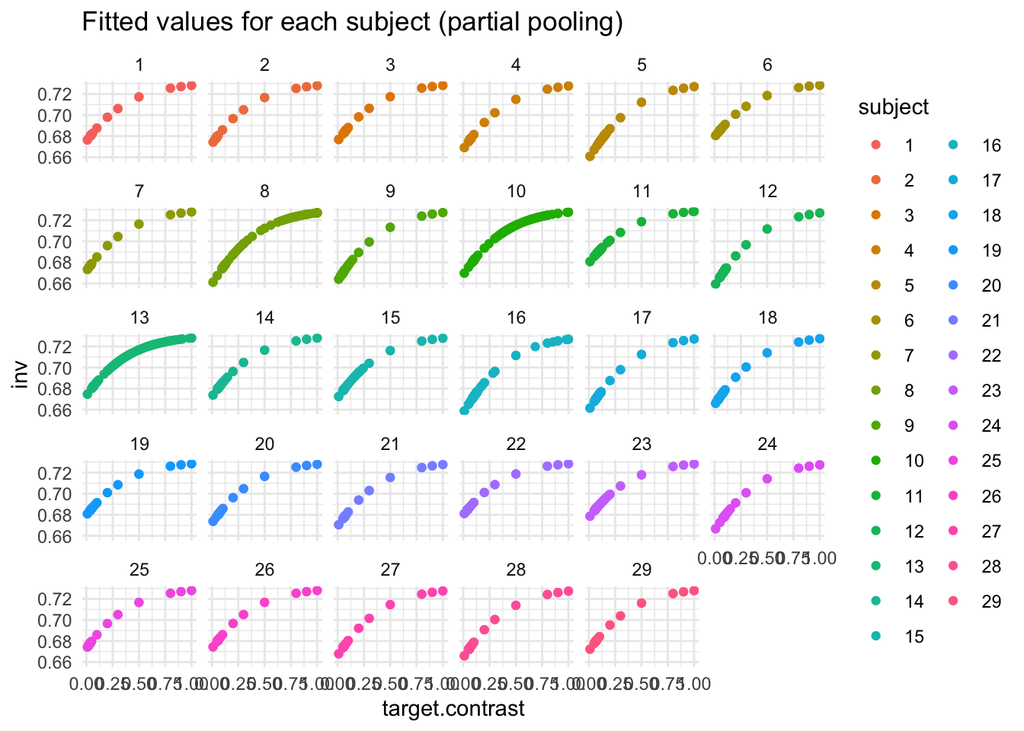

```r
df_f <- df_f %>%
  mutate(inv = inv.logit(fitted.values(model_2)))

ggplot(df_f, aes(x = target.contrast, y = inv, color = subject)) +
  geom_point() +
  theme_minimal() +
  labs(title = "Fitted values for each subject (partial pooling)") +
  facet_wrap(~subject)
```

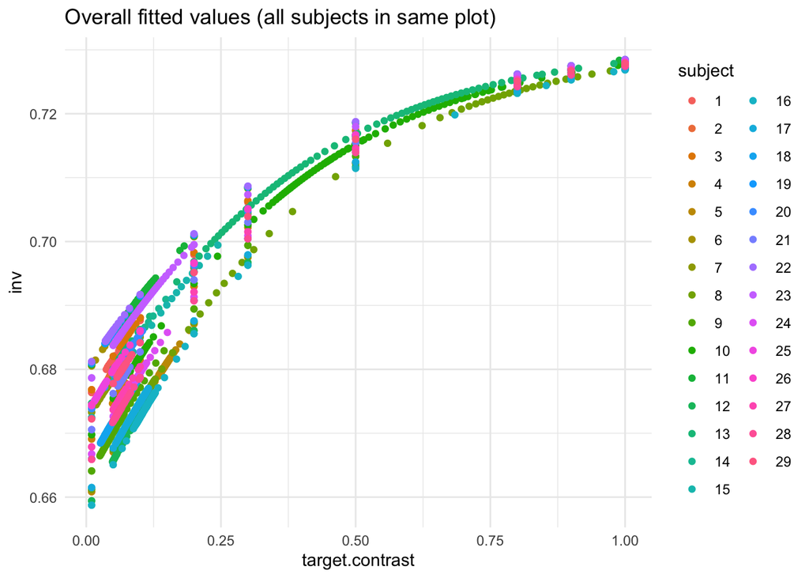

```r
ggplot(df_f, aes(x = target.contrast, y = inv, color = subject)) +
  geom_point() +
  theme_minimal() +
  labs(title = "Overall fitted values (all subjects in same plot)")
```

*NB! After a lot of research, I still wasn’t able to find a solution with the ggplot2 package to add a new layer to the already existing plot with parameters from a separate model. I do understand the goal of the exercise and I an intuition about it, however, I was not fully able to succeed in overlaying. I am not confident in other plot tools and packages to know their syntax and how to reach the goal of combining these two. I have chosen to prioritize learning exactly when I have the time to fully understand how to implement it.*

**v. in your own words, describe how the partial pooling model allows for a better fit for each subject**

When making a no pooling model, one is not able to draw any generalizations. Each fit is based on a specific subject. With partial pooling, one is able to draw the bigger picture, however at the same time, still able to take individual differences into account. Here, the fit is not only based on the subject, but the “grand mean” is als taken into account, and this allow us to a greater extent to make generalizations from the model.

## Exercise 2

*Now we **only** look at the *experiment* trials (*trial.type*)*

#### 1) Pick four subjects and plot their Quantile-Quantile (Q-Q) plots for the residuals of their objective response times (*rt.obj*) based on a model where only intercept is modelled

```r
# Choosing four subjects (1, 6, 11, 15)

df_e <- df %>%
  filter(trial.type == "experiment")

df_s1 <- df_e %>%
  filter(subject == 1)

model_s1 <- glm(rt.obj~1, data=df_s1)

df_s6 <- df_e %>%
  filter(subject == 6)

model_s6 <- glm(rt.obj~1, data=df_s6)


df_s11 <- df_e %>%
  filter(subject == 11)

model_s11 <- glm(rt.obj~1, data=df_s11)


df_s15 <- df_e %>%
  filter(subject == 15)

model_s15 <- glm(rt.obj~1, data=df_s15)
```

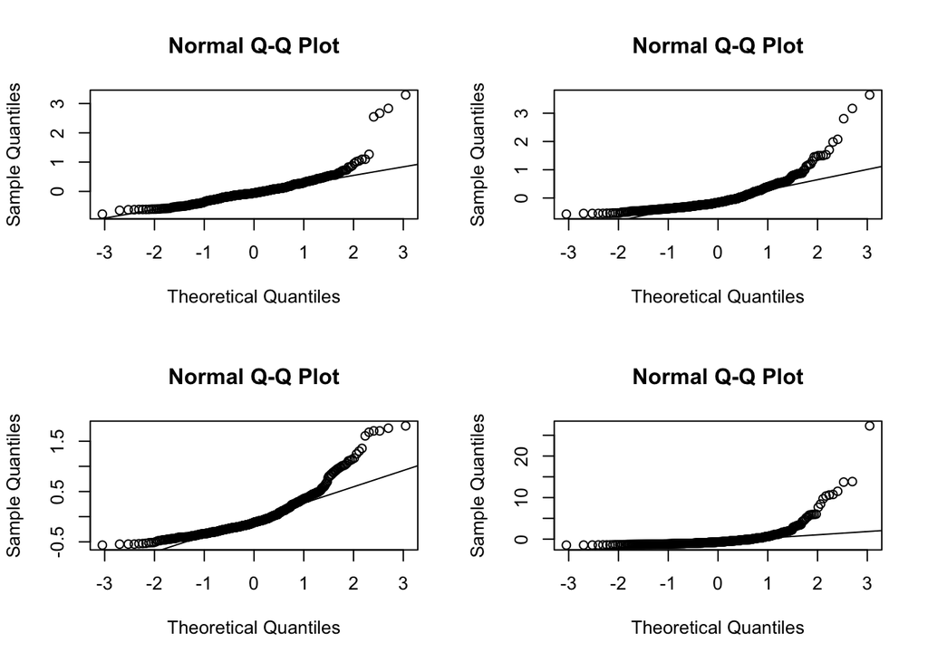

```r
# Making a 2x2 plot grid
par(mfrow = c(2, 2))

qqnorm(residuals(model_s1))
qqline(residuals(model_s1))

qqnorm(residuals(model_s6))
qqline(residuals(model_s6))

qqnorm(residuals(model_s11))
qqline(residuals(model_s11))

qqnorm(residuals(model_s15))
qqline(residuals(model_s15))
```

**i. comment on these**

A visual inspection indicates that none of the residuals of the subjects’ objective response times look normally distributed. For all four subjects, the distribution seems to be positively skewed.

**ii. does a log-transformation of the response time data improve the Q-Q-plots?**

```r
# model with log-transformation
model_s1_log <- glm(log(rt.obj)~1, data=df_s1)
model_s6_log <- glm(log(rt.obj)~1, data=df_s6)
model_s11_log <- glm(log(rt.obj)~1, data=df_s11)
model_s15_log <- glm(log(rt.obj)~1, data=df_s15)
```

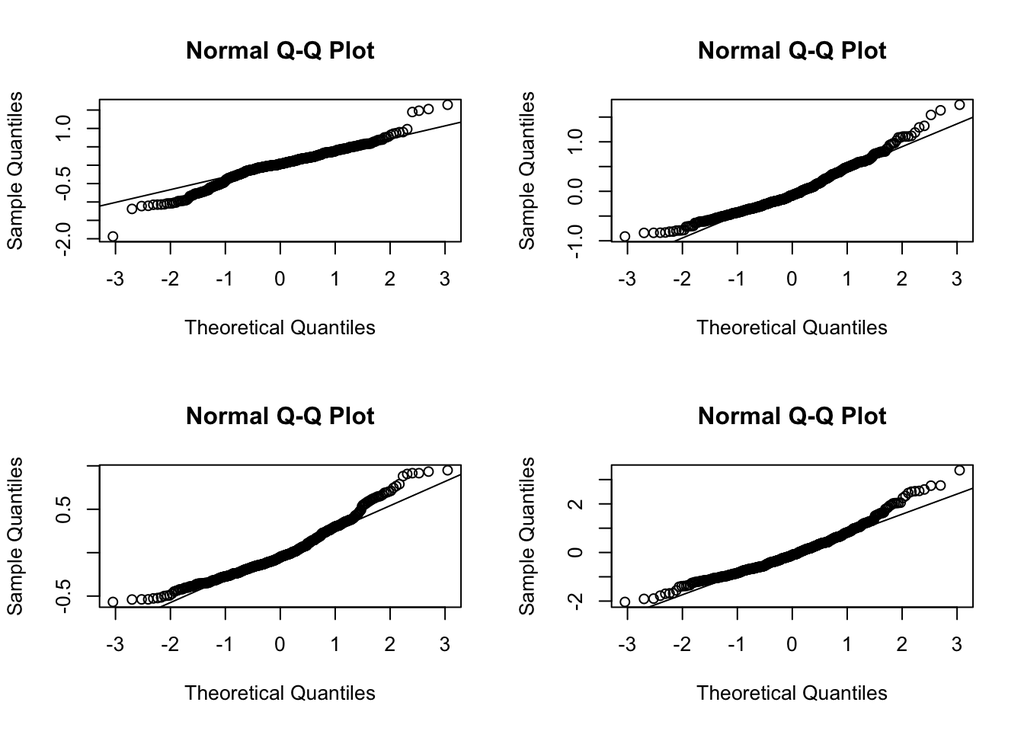

```r
# Making a 2x2 plot grid
par(mfrow = c(2, 2))

qqnorm(residuals(model_s1_log))
qqline(residuals(model_s1_log))

qqnorm(residuals(model_s6_log))
qqline(residuals(model_s6_log))

qqnorm(residuals(model_s11_log))
qqline(residuals(model_s11_log))

qqnorm(residuals(model_s15_log))
qqline(residuals(model_s15_log))
```

Yes. Log-transformation seems to improve the Q-Q-plots to a great extent. The Q-Q-plots still seem to have a positive skew, however, the skew seems to be much smaller than before.

#### 2) Now do a partial pooling model modelling objective response times as dependent on *task* (set `REML=FALSE` in your `lmer`-specification)

**i. which would you include among your random effects and why? (support your choices with relevant measures, taking into account variance explained and number of parameters going into the modelling)**

In the model, subject is included as a random intercept. Because of the experiment being a repeated measures design, one cannot get by without accounting for subject - that would violate the assumption of independence.

```r
model_2.2 <- lmer(rt.obj ~ task + (1 | subject), data = df_e, REML = FALSE)

fixef(model_2.2)
```

```
##    (Intercept) taskquadruplet    tasksingles
##      1.1200841     -0.1532473     -0.1915364
```

**ii. explain in your own words what your chosen models says about response times between the different tasks**

#### 3) Now add *pas* and its interaction with *task* to the fixed effects

```r
model_2.2_int <- lmer(rt.obj ~ task*pas + (1 | subject), data = df_e, REML = FALSE)

fixef(model_2.2_int)
```

```
##         (Intercept)      taskquadruplet         tasksingles                pas2
##          1.33525661         -0.32291080         -0.21563175         -0.13942295
##                pas3                pas4 taskquadruplet:pas2    tasksingles:pas2
##         -0.33590706         -0.57946056          0.22731203          0.12509425
## taskquadruplet:pas3    tasksingles:pas3 taskquadruplet:pas4    tasksingles:pas4
##          0.26239558          0.09453047          0.25827132          0.07097174
```

**i. how many types of group intercepts (random effects) can you add without ending up with convergence issues or singular fits?**

```r
model_2.2_i <- lmer(rt.obj ~ task*pas + (1 | subject) + (1 | cue) + (1 | trial) + (1 | target.type), data = df_e, REML = FALSE)
```

We managed to add four group intercepts without ending up with convergence issues or singular fits.

**ii. create a model by adding random intercepts (without modelling slopes) that results in a singular fit - then use `print(VarCorr(<your.model>), comp='Variance')` to inspect the variance vector - explain why the fit is singular.

```r
model_2.2_ii <- lmer(rt.obj ~ task*pas + (1 | subject) + (1 | cue) + (1 | trial) + (1 | target.type) + (1 | pas), data = df_e, REML = FALSE)
```

```
## boundary (singular) fit: see ?isSingular
```

```r
print(VarCorr(model_2.2_ii), comp='Variance')
```

```
##  Groups      Name        Variance
##  trial       (Intercept) 0.0015785
##  cue         (Intercept) 0.0901493
##  subject     (Intercept) 0.0979532
##  pas         (Intercept) 0.0000000
##  target.type (Intercept) 0.0021986
##  Residual                8.1114287
```

*?isSingular = “Evaluates whether a fitted mixed model is (almost / near) singular, i.e., the parameters are on the boundary of the feasible parameter space: variances of one or more linear combinations of effects are (close to) zero.”*  
A singular model is detected when the variance of some effect is (close to) zero or when estimates of correlations that are (almost) exactly -1 or 1. When working with random effects, singularity is relatively easy to detect. In the output, we see that the variance of *PAS* is zero, which means that *PAS* does not count for any variance.

**iii. in your own words - how could you explain why your model would result in a singular fit?**

## Exercise 3

#### 1) Initialise a new data frame, `data.count`. *count* should indicate the number of times they categorized their experience as *pas* 1-4 for each *task*. I.e. the data frame would have for subject 1: for task:singles, pas1 was used # times, pas2 was used # times, pas3 was used # times and pas4 was used # times. You would then do the same for task:pairs and task:quadruplet

```r
data.count <- df %>%
  group_by(subject, task, pas) %>%
  summarise("count" = n())
data.count$subject <- as.factor(data.count$subject)
data.count$task <- as.factor(data.count$task)
data.count$pas <- as.factor(data.count$pas)
data.count$count <- as.numeric(data.count$count)

head(data.count)
```

```
## # A tibble: 6 x 4
## # Groups:   subject, task [2]
##   subject task       pas   count
##   <fct>   <fct>      <fct> <dbl>
## 1 1       pairs      1       109
## 2 1       pairs      2        45
## 3 1       pairs      3         4
## 4 1       pairs      4        12
## 5 1       quadruplet 1       141
## 6 1       quadruplet 2        23
```

#### 2) Now fit a multilevel model that models a unique “slope” for *pas* for each *subject* with the interaction between *pas* and *task* and their main effects being modelled

```r
model_3.2.interaction <- lme4::glmer(count~pas*task + (1+pas|subject),
                                     data = data.count,
                                     family = poisson,
                                     glmerControl(optimizer="bobyqa")) #Control added

summary(model_3.2.interaction)$coefficients
```

```
##                        Estimate Std. Error    z value      Pr(>|z|)
## (Intercept)          4.03570050 0.10975841 36.7689419 5.791904e-296
## pas2                -0.02377584 0.11962643 -0.1987507  8.424578e-01
## pas3                -0.51364686 0.20717747 -2.4792603  1.316552e-02
## pas4                -0.77292109 0.29075441 -2.6583297  7.852902e-03
## taskquadruplet       0.11490028 0.03127248  3.6741664  2.386272e-04
## tasksingles         -0.23094586 0.03418208 -6.7563437  1.415175e-11
## pas2:taskquadruplet -0.11375485 0.04605307 -2.4700817  1.350822e-02
## pas3:taskquadruplet -0.20901449 0.05286546 -3.9537058  7.695001e-05
## pas4:taskquadruplet -0.21500417 0.05229940 -4.1110253  3.939061e-05
## pas2:tasksingles     0.19536317 0.04829802  4.0449516  5.233393e-05
## pas3:tasksingles     0.24299422 0.05369200  4.5257061  6.019420e-06
## pas4:tasksingles     0.56346205 0.05101391 11.0452628  2.310906e-28
```

**i. which family should be used?** The “poisson” family is used when the dependent variable consists of count data, which is the case here.

**ii. why is a slope for *pas* not really being modelled?** *PAS* is modeled as a factor, and therefore it is not on a continuum (the pas indicators (1,2,3,4) have to be classified categorically), which is required for it to be modelled as a “proper slope”. We only have estimates for each pas, no estimate ‘in between’ pas (e.g. pas 1.5 does not exist).

**iii. if you get a convergence error, try another algorithm (the default is the *Nelder_Mead*) - try (*bobyqa*) for which the `dfoptim` package is needed. In `glmer`, you can add the following for the `control` argument: `glmerControl(optimizer="bobyqa")` (if you are interested, also have a look at the function `allFit`)**

**iv. when you have a converging fit - fit a model with only the main effects of *pas* and *task*. Compare this with the model that also includes the interaction.**

```r
model_3.2 <- lme4::glmer(count ~ pas + task + (1+pas|subject), data = data.count, family = poisson, glmerControl(optimizer="bobyqa"))

summary(model_3.2)$coefficients # looking at the fixed effects (we no longer have any interactions)
```

```
##                    Estimate Std. Error     z value      Pr(>|z|)
## (Intercept)     4.004589193 0.10872397 36.83262437 5.549747e-297
## pas2           -0.006528074 0.11661554 -0.05597945  9.553582e-01
## pas3           -0.509918222 0.20445185 -2.49407481  1.262859e-02
## pas4           -0.663832458 0.29196205 -2.27369432  2.298437e-02
## taskquadruplet  0.003293922 0.01818768  0.18110735  8.562833e-01
## tasksingles     0.004306887 0.01817725  0.23693831  8.127046e-01
```

**v. indicate which of the two models, you would choose and why**

```r
AIC(model_3.2, model_3.2.interaction)
```

```
##                       df      AIC
## model_3.2             16 3398.549
## model_3.2.interaction 22 3148.441
```

The interactions seem to have an significant impact on the independent variables, and they should therefore be kept. Also, the AIC output indicates that the model with the interaction is a better fit.

**vi. based on your chosen model - write a short report on what this says about the distribution of ratings as dependent on *pas* and *task*.**

When pas = 1 and task = pairs, one expects the outcome to be exp(4.03570) ≈ 56.58. According to the model, going from pas 1 to either pas 2, 3 or 4 will result in a decrease of the ratings, however, these predictions are only significant for pas 3 and 4, *p* < .05.

Going to the quadruplet task, the model predicts an increase in outcome by ≈12%, while going from pairs to singles task, the model predicts a decrease of ≈21%. Both of these estimates are significant, *p* < .05.

The model shows a decrease for all interactions between passes and the quadruplet tasks, while it shows an increase for all interaction between passes and singles tasks. The model indicates that all interactions are significant, *p* < .05.

**vii. include a plot that shows the estimated amount of ratings for four subjects of your choosing**

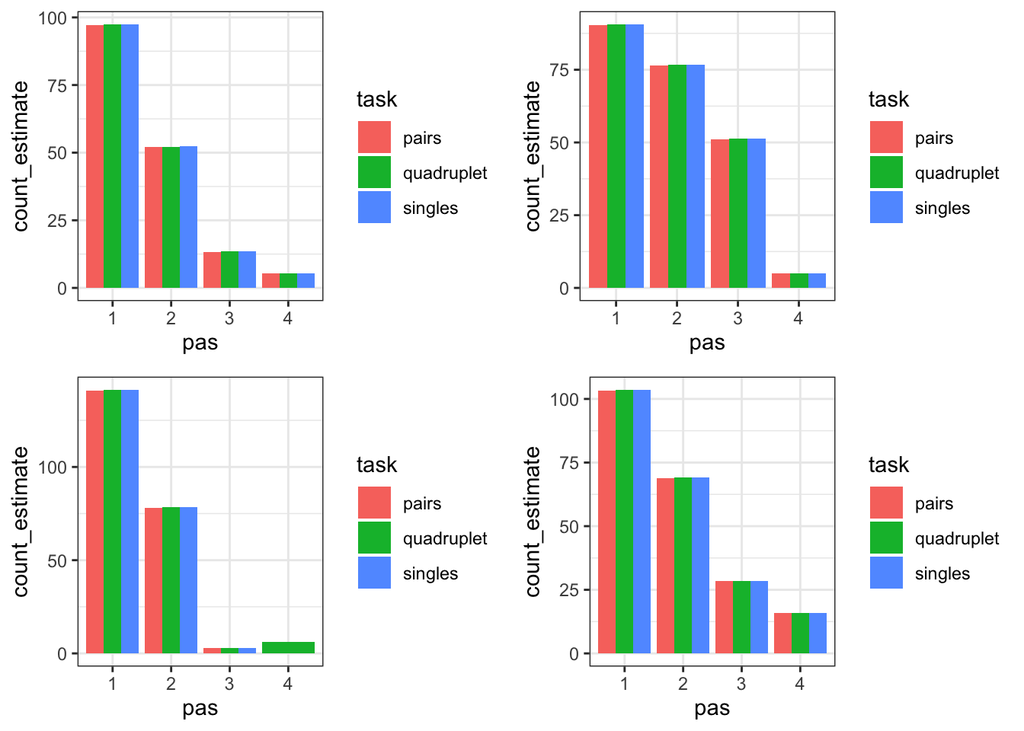

```r
d_s1 <- data.count %>%filter(subject == 1)
d_s5 <- data.count %>%filter(subject == 5)
d_s12 <- data.count %>%filter(subject == 12)
d_s27 <- data.count %>%filter(subject == 27)

est_val <- function(sub, model) {
  sub_pred <- predict(model, newdata = sub)
  sub$count_estimate <- expm1(sub_pred)

  # Make plot
  plot <- ggplot(sub) +
    geom_bar(aes(x=pas, y=count_estimate, fill = task), stat = "identity", position = "dodge") +
    theme_bw()

  return(plot)
}

s1_plot <- est_val(d_s1, model_3.2)
s5_plot <- est_val(d_s5, model_3.2)
s12_plot <- est_val(d_s12, model_3.2)
s27_plot <- est_val(d_s27, model_3.2)

# arrange with ggplot
ggpubr::ggarrange(s1_plot, s5_plot, s12_plot, s27_plot)
```

#### 3) Finally, fit a multilevel model that models *correct* as dependent on *task* with a unique intercept for each *subject*.

as dataset is not specified for Exercise 3, it is chosen to work with the data in trial.type = experiment.

```r
model_e3.1 <- lme4::glmer(correct ~ task + (1 | subject), data = df_e, family = "binomial")

summary(model_e3.1)$coefficients
```

```
##                   Estimate Std. Error   z value     Pr(>|z|)
## (Intercept)     1.11895745 0.11774465  9.503255 2.034301e-21
## taskquadruplet -0.07495836 0.05080966 -1.475278 1.401379e-01
## tasksingles     0.16603066 0.05217791  3.182011 1.462564e-03
```

**i. does *task* explain performance?**

Looking at the *p*-values in the output, it indicates that task does explain performance significantly. However, we can only detect an effect, not the size of the effect.

**ii. add *pas* as a main effect on top of *task* - what are the consequences of that?**

```r
model_e3.2 <- lme4::glmer(correct ~ task + pas + (1 | subject), data = df_e, family = "binomial")
summary(model_e3.2)$coefficients
```

```
##                   Estimate Std. Error    z value      Pr(>|z|)
## (Intercept)     0.14962772 0.10252325  1.4594516  1.444408e-01
## taskquadruplet -0.02658991 0.05367383 -0.4953981  6.203192e-01
## tasksingles    -0.03641270 0.05568297 -0.6539288  5.131577e-01
## pas2            0.88735895 0.05414113 16.3897375  2.264202e-60
## pas3            1.87054609 0.07482158 25.0000883 6.099886e-138
## pas4            2.88684764 0.10238305 28.1965401 6.447611e-175
```

Here, *PAS* has a significant effect on performance, where task no longer seems to have a significant effect on performance. Thus, adding *PAS* to the model changes the effect that task has on the performance.

**iii. now fit a multilevel model that models *correct* as dependent on *pas* with a unique intercept for each *subject***

```r
model_e3.3 <- lme4::glmer(correct ~ pas + (1 | subject), data = df_e, family = "binomial")
summary(model_e3.3)$coefficients
```

```
##              Estimate Std. Error   z value      Pr(>|z|)
## (Intercept) 0.1301357 0.09789466  1.329344  1.837346e-01
## pas2        0.8863758 0.05406860 16.393542  2.126814e-60
## pas3        1.8689071 0.07461743 25.046523 1.904981e-138
## pas4        2.8819760 0.10168518 28.342144 1.046071e-176
```

**iv. finally, fit a model that models the interaction between *task* and *pas* and their main effects**

```r
model_e3.4 <- lme4::glmer(correct ~ pas*task + (1 | subject), data = df_e, family = "binomial")
summary(model_e3.4)$coefficients
```

```
##                        Estimate Std. Error    z value     Pr(>|z|)
## (Intercept)          0.14959690 0.10793596  1.3859783 1.657535e-01
## pas2                 0.91504591 0.08888640 10.2945547 7.456374e-25
## pas3                 1.82975050 0.12082999 15.1431818 8.404698e-52
## pas4                 2.83306066 0.17327867 16.3497365 4.368654e-60
## taskquadruplet       0.03067819 0.07758141  0.3954323 6.925239e-01
## tasksingles         -0.11075806 0.08400069 -1.3185375 1.873238e-01
## pas2:taskquadruplet -0.11915127 0.12075462 -0.9867222 3.237788e-01
## pas3:taskquadruplet -0.06631244 0.16761063 -0.3956338 6.923752e-01
## pas4:taskquadruplet -0.17372846 0.23469019 -0.7402459 4.591508e-01
## pas2:tasksingles     0.05845703 0.12715694  0.4597235 6.457147e-01
## pas3:tasksingles     0.20714922 0.17117450  1.2101640 2.262160e-01
## pas4:tasksingles     0.28174233 0.22708475  1.2406924 2.147194e-01
```

**v. describe in your words which model is the best in explaining the variance in accuracy**

```r
# Inspecting residual variance

res_1 <- sqrt(sum(residuals(model_e3.1)^2))
res_2 <- sqrt(sum(residuals(model_e3.2)^2))
res_3 <- sqrt(sum(residuals(model_e3.3)^2))
res_4 <- sqrt(sum(residuals(model_e3.4)^2))

# Inspecting AIC scores
AICs <- AIC(model_e3.1, model_e3.2, model_e3.3, model_e3.4)

tibble("Model"=c("Model 1: Correct ~ Task","Model 2: Correct ~ Task + Pas", "Model 3: Correct ~ Pas", "Model 4: Correct ~ Pas*Task"), "Residual Variance"=c(res_1, res_2, res_3, res_4), "AIC"=c(AICs[1,2], AICs[2,2], AICs[3,2], AICs[4,2]))
```

```
## # A tibble: 4 x 3
##   Model                         `Residual Variance`    AIC
##   <chr>                                       <dbl>  <dbl>
## 1 Model 1: Correct ~ Task                      116. 13636.
## 2 Model 2: Correct ~ Task + Pas                110. 12260.
## 3 Model 3: Correct ~ Pas                       110. 12257.
## 4 Model 4: Correct ~ Pas*Task                  110. 12266.
```